# HW1

#### FCB 4.7

Mixture models: After a posterior analysis on data from a population of squash plants, it was determined that the total vegetable weight of a given plant could be modeled with the following distribution:

$p(y|\theta, \sigma^2) = .31dnorm(y, \theta, \sigma) + .46dnorm(2\theta_1, 2\sigma) + .23dnorm(y, 3\theta_1, 3\sigma)$

where the posterior distributions of the parameters have been calculated as $1/\sigma^2 \sim gamma(10, 2.5)$, and $\theta|\sigma^2 \sim normal(4.1, sigma^2/20)$.

1. Sample at least 5,000 $y$ values from the posterior predictive distribution.

```r
set.seed(59)
Sigma <- matrix(1/rgamma(75, 10, 2.5))

Theta <- matrix()
for (i in 1:75) {
  sigma <- Sigma[i]
  Theta[i] <- rnorm(1, 4.1, sigma/20)
}
Theta <- matrix(Theta)

y <- matrix(nrow=75, ncol=75)
for (i in 1:75) {
  sigma <- Sigma[i]
  for (j in 1:75) {
    theta <- Theta[j]
    y[j, i] <- 0.31*rnorm(1, theta, sqrt(sigma)) + 0.46*rnorm(1, 2*theta, 2*sqrt(sigma)) + 0.23*rnorm(1, 3*theta, 3*sqrt(sigma))
  }
}

str(y)
```

```
##  num [1:75, 1:75] 7.78 7.32 8.59 7.56 8.15 ...
```

2. Form a 75% quantile-based confidence interval for a new value of $Y$.

```r
q <- quantile(y, probs=c(0.125, 0.875))
q
```

```
##    12.5%    87.5%
## 7.161198 8.593201
```

3. Form a 75% HPD region for a new $Y$ as follows:
1. Compute estimates of the posterior density of $Y$ using the `density` command in R, and then normalize the density values so they sum to 1.

```r
density(y)
```

```
##
## Call:
##  density.default(x = y)
##
## Data: y (5625 obs.); Bandwidth 'bw' = 0.1013
##
##        x                y
##  Min.   : 5.077   Min.   :0.0000079
##  1st Qu.: 6.494   1st Qu.:0.0036565
##  Median : 7.912   Median :0.0556079
##  Mean   : 7.912   Mean   :0.1761560
##  3rd Qu.: 9.330   3rd Qu.:0.3384702
##  Max.   :10.748   Max.   :0.6240401
```

```r
d <- density(y)
head(d[["y"]]); sum(d[["y"]])
```

```
## [1] 1.625289e-05 2.267292e-05 3.119438e-05 4.234244e-05 5.672233e-05
## [6] 7.501835e-05
```

```
## [1] 90.19186
```

```r
d[["y"]] <- d[["y"]]/sum(d[["y"]])

head(d[["y"]]); sum(d[["y"]])
```

```
## [1] 1.802036e-07 2.513854e-07 3.458669e-07 4.694707e-07 6.289073e-07
## [6] 8.317641e-07
```

```
## [1] 1
```

2. Sort these discrete probabilities in decreasing order.

```r
d.sort <- sort(d[["y"]], decreasing=TRUE)
head(d.sort)
```

```
## [1] 0.006919029 0.006917517 0.006916595 0.006912582 0.006909345 0.006904783
```

3. Find the first probability value such that the cumulative sum of the sorted values exceeds 0.75. Your HPD region includes all values of $y$ which have a discretized probability greater than this cutoff. Describe your HPD region, and compare it to your quantile-based region.

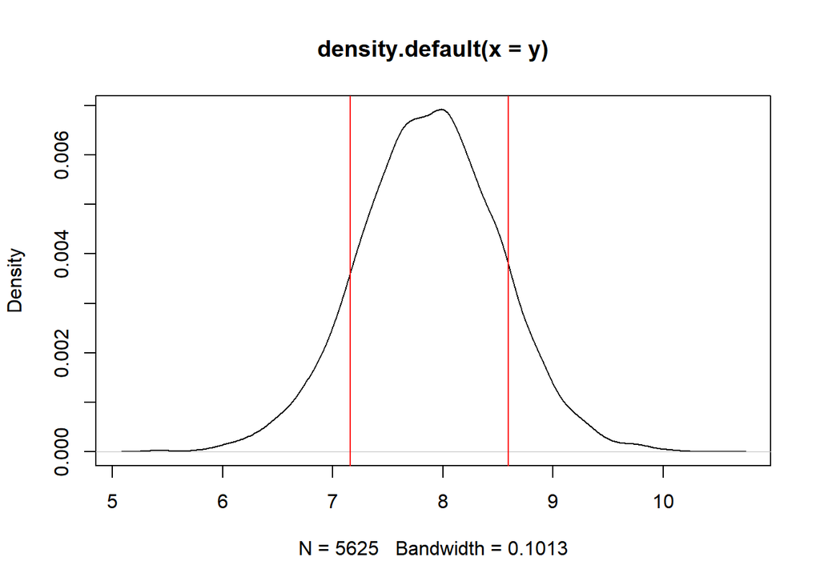

```r
plot(d)
abline(v=q[1], col="red")
abline(v=q[2], col="red")
```